# Case Study 2

Zoheb Allam

December 8, 2016

# Question 1

This is the code for creating the matrix and printing it from SAS.

proc iml; reset print; x={4 5 1 2, 1 0 3 5, 2 1 8 2};

quit;

This is the code for creating the matrix and printing it from R .

```r
X = matrix(
   c(4,1,2,5,0,1,1,3,8,2,5,2),
   nrow=3,
   ncol=4)
X
```

```
##      [,1] [,2] [,3] [,4]
## [1,]    4    5    1    2
## [2,]    1    0    3    5
## [3,]    2    1    8    2
```

This is the code for creating the matrix and printing it from Python.

import numpy as np X = np.matrix(‘4 5 1 2; 1 0 3 5; 2 1 8 2’) print (X)

# Question 2

This is the code to download the data

```r
library(tseries)
```

```r
AGIOdata <- get.hist.quote('AGIO',quote="Close")
```

```
## time series starts 2013-07-24
```

This is the code to calculate log returns and volatility

```r
AGIOret <- log(lag(AGIOdata)) - log(AGIOdata)
AGIOvol <- sd(AGIOret) * sqrt(250) * 100
```

This is the function for volatility

```r
getVol <- function(d, logrets)
{

  var = 0

  lam = 0

  varlist <- c()

  for (r in logrets) {

    lam = lam*(1 - 1/d) + 1

    var = (1 - 1/lam)*var + (1/lam)*r^2

    varlist <- c(varlist, var)

  }

  sqrt(varlist)
}
```

This is the code for calculating volatility over the length of series for the different decay factors and the plot with the results.

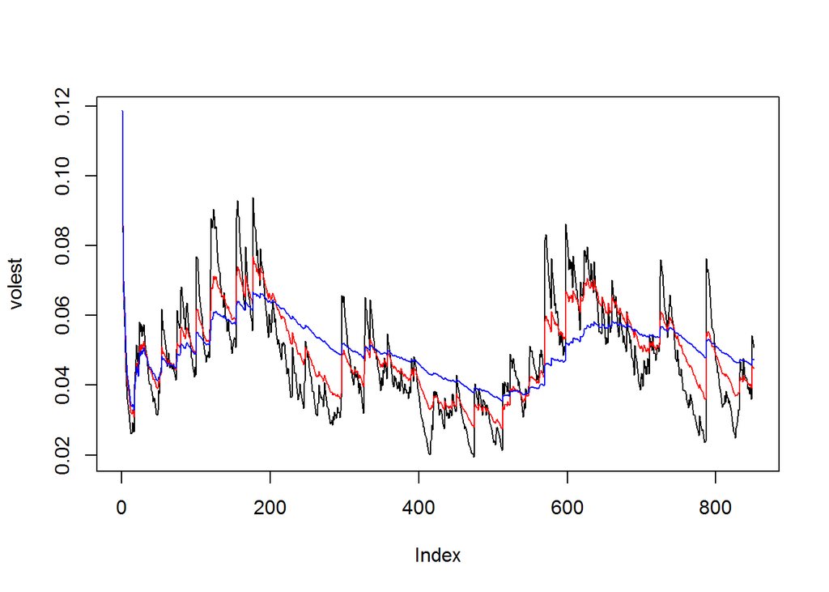

```r
volest <- getVol(10,AGIOret)

volest2 <- getVol(30,AGIOret)

volest3 <- getVol(100,AGIOret)

plot(volest,type="l")

lines(volest2,type="l",col="red")

lines(volest3, type = "l", col="blue")
```

# Question 3

This is the code for downloading the Organge data set.

```r
data(Orange)
Orange
```

```
##    Tree  age circumference
## 1     1  118            30
## 2     1  484            58
## 3     1  664            87
## 4     1 1004           115
## 5     1 1231           120
## 6     1 1372           142
## 7     1 1582           145
## 8     2  118            33
## 9     2  484            69
## 10    2  664           111
## 11    2 1004           156
## 12    2 1231           172
## 13    2 1372           203
## 14    2 1582           203
```

[output cut: 21 more lines]

This code calculates the mean and the median of the trink circumference for different sizes of the trees.

```r
mean <- tapply(Orange$circumference,Orange$Tree, mean,  na.rm=TRUE)
median <- tapply(Orange$circumference,Orange$Tree, median,  na.rm=TRUE)
cbind(mean, median)
```

```
##        mean median
## 3  94.00000    108
## 1  99.57143    115
## 5 111.14286    125
## 2 135.28571    156
## 4 139.28571    167
```

This code makes a scatter plot of the trunk circumference against the age of the trees.

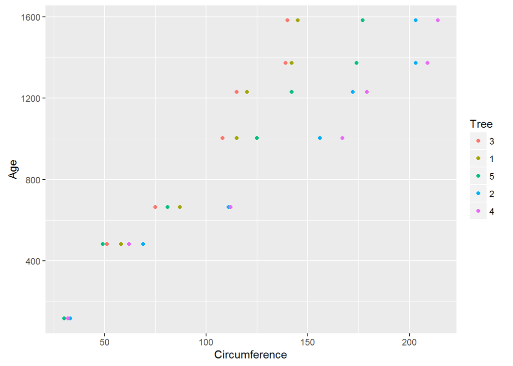

```r
library (ggplot2)
qplot(circumference, age, data=Orange,color=Tree,
      xlab="Circumference", ylab="Age")
```

This code displays the trunk circumference on a comparitive boxplot against trees in increasing order.

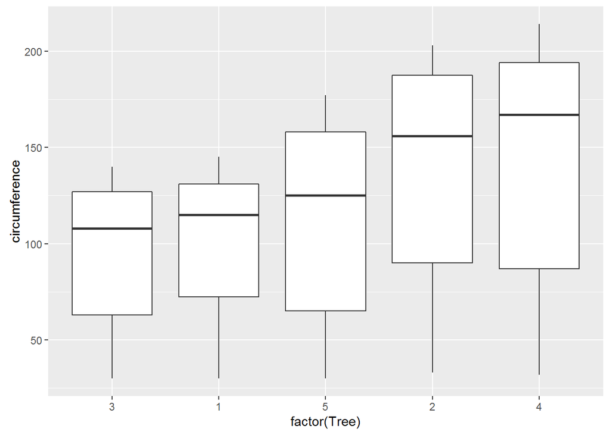

```r
qplot(factor(Tree), circumference, data = Orange, geom = "boxplot")
```

# Question 4

### The next set of codes answer part i of Question 4.

The first step is to download the data into R.

```r
setwd("C:/Users/Laptop/Desktop/CaseStudy_2")
TempData <- read.csv("TEMP.csv", header=T, na.strings=c("","NA"))
```

In order to work with the year variable, we need to create a new variable that only has the year information.

```r
TempData$Year = as.numeric(gsub("^.*([0-9]{4}).*$", "\\1" , TempData$Date))
```

Since there are a lot of missing in the data file and the missing is for both the average temp variables, we can drop rows from the data with missing information.

```r
TempDataComplete = TempData[!is.na(TempData$Monthly.AverageTemp),]
```

Then we write a function that gives us the difference between the max and the min monthly average and we run it on the data file.

```r
rangediff = function(x) {
  range = range(x)
  range[2] - range[1]
}
TempData2 = tapply(TempDataComplete$Monthly.AverageTemp, TempDataComplete$Country, rangediff)
str(TempData2)
```

```
##  num [1:242(1d)] 33.09 7.6 27.89 26.3 3.83 ...
##  - attr(*, "dimnames")=List of 1
##   ..$ : chr [1:242] "Afghanistan" "Africa" "Albania" "Algeria" ...
```

Since the question asks only for data from 1900, we create a new data file from the Year variable that only contains data for 1900 and up.

```r
TempData1900plus = TempDataComplete[TempDataComplete$Year >= "1900",]
```

```r
TempDataRanges = tapply(TempData1900plus$Monthly.AverageTemp, TempData1900plus$Country, rangediff)
Rangestop20 = sort(TempDataRanges)[1:20]
Rangestop20
```

```
##                          Indonesia     Federated States Of Micronesia
##                              2.914                              2.976
##                    Solomon Islands                              Palau
##                              3.391                              3.469
##                              Samoa                           Colombia
##                              3.808                              3.811
##                     American Samoa                      Palmyra Atoll
##                              3.831                              3.835
##                       Kingman Reef                             Guyana
##                              3.839                              3.992
##                   Christmas Island                               Guam
##                              4.098                              4.108
##           Northern Mariana Islands                   Papua New Guinea
##                              4.108                              4.150
##                         Seychelles                       Baker Island
##                              4.250                              4.298
##                      French Guiana                           Kiribati
##                              4.401                              4.425
##                           Suriname Congo (Democratic Republic Of The)
##                              4.435                              4.466
```

Then we can plot the relationship.

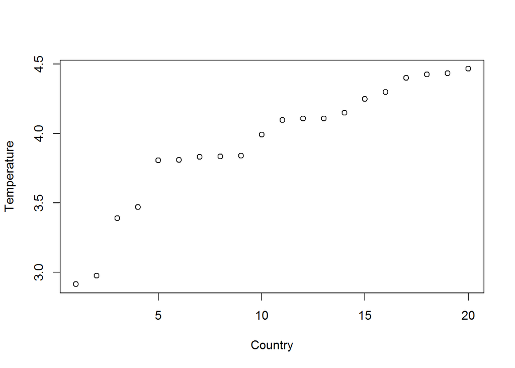

```r
plot(Rangestop20, xlab = "Country", ylab = "Temperature")
```

### The next set of codes answer part ii of Question 4.

The code below creates a subset of the data file with only data points of the US from 1990 and up.

```r
TempsData1990plus = TempDataComplete[TempDataComplete$Year >= "1990",]
USTempData = TempsData1990plus[TempsData1990plus$Country == 'United States',]
```

```r
library(weathermetrics)
USTempData$temp.fahr <- celsius.to.fahrenheit(USTempData$Monthly.AverageTemp, round = 2)
```

Then we calculate average lang temperature by year and plot it.

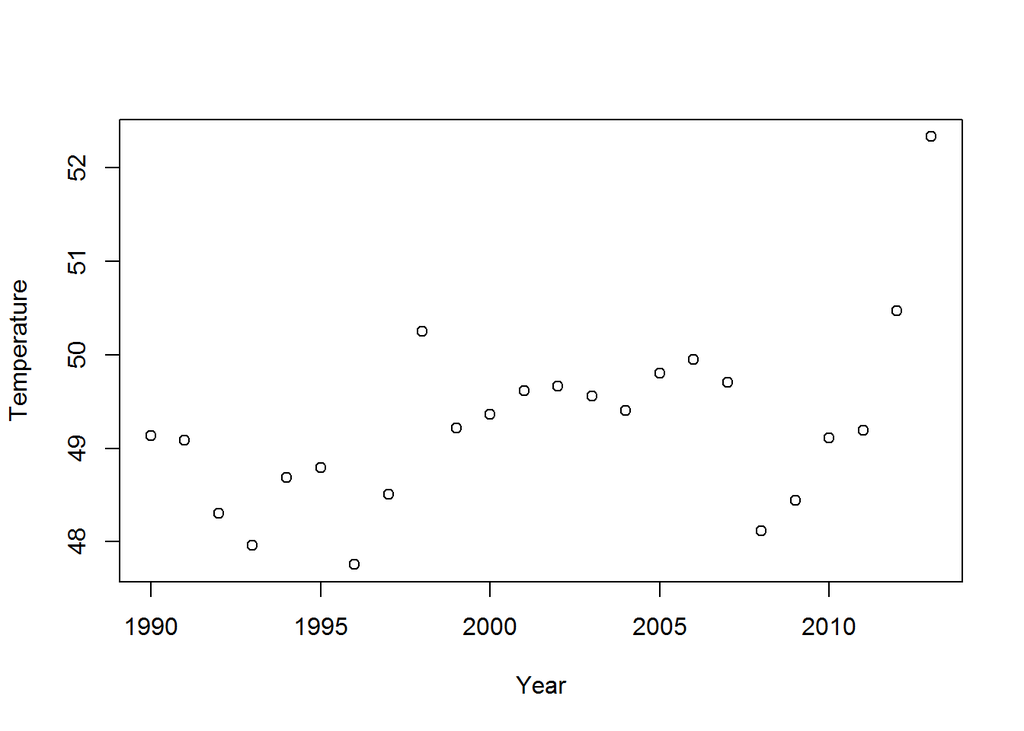

```r
UStempavtemp = tapply(USTempData$temp.fahr, USTempData$Year, mean)
xaxis = 1990 + 0:(length(UStempavtemp)-1)
plot(xaxis, UStempavtemp, xlab = 'Year', ylab='Temperature')
```

### The next set of codes answer part iii of Question 4.

The code below downloads the data for cities into R.

```r
CityTempData <- read.csv("CityTemp.csv", header=T, na.strings=c("","NA"))
```

The code below changes the original date variable to only have information on the year. We then drop the rows that are missing from the data.

```r
CityTempData$Year = as.numeric(gsub("^.*([0-9]{4}).*$", "\\1" , CityTempData$Date))
CityTempComplete = CityTempData[!is.na(CityTempData$Monthly.AverageTemp),]
```

Using the same function as before, we find the difference between the min and max temps but we do this now by City instead of Country.

```r
CityTempData2 = tapply(CityTempComplete$Monthly.AverageTemp, CityTempComplete$City, rangediff)
str(CityTempData2)
```

```
##  num [1:99(1d)] 6.69 18.63 31.96 18.58 32.32 ...
##  - attr(*, "dimnames")=List of 1
##   ..$ : chr [1:99] "Addis Abeba" "Ahmadabad" "Aleppo" "Alexandria" ...
```

Since the questions asks only for data from 1900 and up, we create a new data file with only that information.

```r
CityTempData1900plus = CityTempComplete[CityTempComplete$Year >= "1900",]
```

```r
CityTempDataRanges = tapply(CityTempData1900plus$Monthly.AverageTemp, CityTempData1900plus$City, rangediff)
CityRangestop20 = sort(CityTempDataRanges)[1:20]
CityRangestop20
```

```
##          Jakarta          BogotÃ¡            Lagos             Cali
##            3.642            4.306            4.481            4.578
##        Singapore         Surabaya        Mogadishu        Fortaleza
##            4.757            4.946            5.566            5.652
##         Kinshasa    Santo Domingo          Nairobi         Salvador
##            5.864            6.072            6.142            6.604
##      Addis Abeba    Dar Es Salaam           Ibadan           Manila
##            6.695            6.733            7.139            7.376
## Ho Chi Minh City        Bangalore           Luanda        BrasÃlia
##            7.716            8.399            8.480            8.725
```

We then plot the relationship.

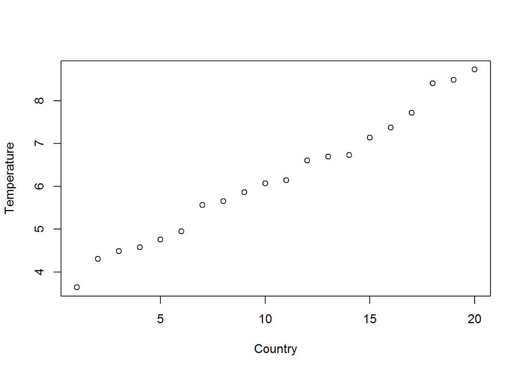

```r
plot(CityRangestop20, xlab = "Country", ylab = "Temperature")
```